# L2 Portoflio Returns

FIN 3380: Introduction to Financial Data Analysis

Week 2-3

# Load Packages

```r
setwd("C:/Users/siche/Documents/teaching/Introduction to Financial Data Analysis/L2")
library(RPostgres)
library(tidyr)
library(dplyr)
```

# Equal Weighted Portfolio, Monthly Reallocation

## Step 1. grab all 10 stocks’ daily returns

- Connect to WRDS
- Use the same random permnos selected, the file contains permnos is called “permnos.RData”
- Use paste0() function to generate quote sent to the CRSP database
- Get daily returns, and close price, shares outstanding for selected stocks
- Save the sample data for future use.
- Only keep permno, date, ret for this equal-weighted portfolio return project

```r
# DO NOT RUN: THIS PIECE OF CODE CONNECT TO WRDS TO GET DATA
# connect to WRDS
source("C:/Users/siche/Documents/teaching/Introduction to Financial Data Analysis/wrds.R")
# use the random permno selected
load("permnos.RData")
permnos = paste0(permnos,collapse = ',')
q=paste0("select permno,date,ret,prc,shrout from CRSP.DSF where permno in (",
         permnos,
         ") and date>='2010-01-01'")
res = dbSendQuery(wrds, q)
crsp.sample = dbFetch(res, n=-1)
dbClearResult(res)
save(crsp.sample,file='crsp.sample.Rdata')
```

- Direct load our previous saved sample data

```r
load("C:/Users/siche/Documents/teaching/Introduction to Financial Data Analysis/L2/crsp.sample.RData")
crsp.sample = crsp.sample %>% select(permno,date,ret)
head(crsp.sample,3)
```

```
##   permno       date          ret
## 1  11600 2010-01-04  0.004549436
## 2  11600 2010-01-05 -0.011887969
## 3  11600 2010-01-06  0.006588357
```

## Step 2. Format returns so that on each date, there are equal number of stocks in the portfolio

- Summarize the data by each stock to check whether each stock has equal number of days in their returns.
- Missing stock returns should be replaced with value 0
- We use the spread() function to turn the long data into a wide one
- We use gather() function to turn the wide data back to the long data so that it can be used by the dplyr package.
- After the two steps above, stockings with missing return on a particular date will have a return NA rather disappear from data.

```r
tmp.summary = crsp.sample %>% group_by(permno) %>% summarise(n=n())
tmp.summary
```

```
## # A tibble: 10 x 2
##    permno     n
##     <dbl> <int>
##  1  11600  2264
##  2  13610  2264
##  3  39731  2264
##  4  79089  2264
##  5  83148  2264
##  6  85459  2264
##  7  86091  2264
##  8  89509  2264
##  9  90029  2262
## 10  91421  2264
```

- The dplyr function summarise() gives a summary number of data.
- The n() function returns the number of observations
- The stock with permno=90029 do not have 2262 days rather than 2264 as other stocks.

```r
# example: use spread() and gather() to retreive missing values
load("ret.example.RData")
ret.example
```

```
##         date stock_id        ret
## 1 2010-01-01   stock1  0.4463222
## 2 2010-01-02   stock1  0.6466551
## 4 2010-01-01   stock2  0.3064323
## 5 2010-01-02   stock2 -0.2082416
## 6 2010-01-03   stock2 -0.4082992
## 7 2010-01-01   stock3 -0.1445946
## 8 2010-01-02   stock3 -0.2612718
## 9 2010-01-03   stock3  0.2074440
```

```r
ret.example.wide = spread(ret.example,key=stock_id,value=ret)
ret.example.wide
```

```
##         date    stock1     stock2     stock3
## 1 2010-01-01 0.4463222  0.3064323 -0.1445946
## 2 2010-01-02 0.6466551 -0.2082416 -0.2612718
## 3 2010-01-03        NA -0.4082992  0.2074440
```

```r
ret.example.long = gather(ret.example.wide,key=stock_id,value=ret,-date)
ret.example.long
```

```
##         date stock_id        ret
## 1 2010-01-01   stock1  0.4463222
## 2 2010-01-02   stock1  0.6466551
## 3 2010-01-03   stock1         NA
## 4 2010-01-01   stock2  0.3064323
## 5 2010-01-02   stock2 -0.2082416
## 6 2010-01-03   stock2 -0.4082992
## 7 2010-01-01   stock3 -0.1445946
## 8 2010-01-02   stock3 -0.2612718
## 9 2010-01-03   stock3  0.2074440
```

```r
# spread function from library(tidyr) to turn a long table into a wide table
# after spread, the days with missing ret will be filled with NA value.
crsp.sample = spread(crsp.sample,key = permno, value = ret)

# the gather function reformat the wide table into long table
# the NA value will be kept
crsp.sample = gather(crsp.sample,key = permno,value = ret,-date)
tmp.summary = crsp.sample %>% group_by(permno) %>% summarise(n=n())
tmp.summary
```

```
## # A tibble: 10 x 2
##    permno     n
##    <chr>  <int>
##  1 11600   2264
##  2 13610   2264
##  3 39731   2264
##  4 79089   2264
##  5 83148   2264
##  6 85459   2264
##  7 86091   2264
##  8 89509   2264
##  9 90029   2264
## 10 91421   2264
```

## Step 3. Calculate the cumulative returns of each stock in each month

- Fill NA with 0 using the ifelse statement
- Create a group label of year-month called yymm
- For each stock, over each month, we calculate the cumulative returns of each stock since we’re rebalancing our portfolio each month

```r
# fill ret with 0 when they're NA, so that within a month,
# each day has equal number of stocks
crsp.sample = crsp.sample %>%
  mutate(ret=ifelse(is.na(ret),0,ret)) %>%
  mutate(date=as.character(date)) %>%
  mutate(yymm=substr(date,1,7)) %>%
  group_by(permno,yymm) %>%
  arrange(date) %>%
  mutate(cumret=cumprod(ret+1)) %>%
  ungroup()
head(crsp.sample,3)
```

```
## # A tibble: 3 x 5
##   date       permno     ret yymm    cumret
##   <chr>      <chr>    <dbl> <chr>    <dbl>
## 1 2010-01-04 11600  0.00455 2010-01   1.00
## 2 2010-01-04 13610  0.0354  2010-01   1.04
## 3 2010-01-04 39731  0.0724  2010-01   1.07
```

## Step 4. the EW portfolio index cumulative return is the simple average of cumulative return of all stocks

- On each day, the equal weighted portfolio return since the beginning of the month is the average of all stocks cumulative returns on that day.
- The summarise() function only keep the group label and the summarised value, thus to keep a label for the month, we use the first() function on the yymm label, which returns the first value of yymm in a column.

```r
crsp.ew = crsp.sample %>%
  group_by(date) %>%
  summarise(ew=mean(cumret),
            yymm=first(yymm)) %>%
  ungroup()
head(crsp.ew)
```

```
## # A tibble: 6 x 3
##   date          ew yymm
##   <chr>      <dbl> <chr>
## 1 2010-01-04  1.02 2010-01
## 2 2010-01-05  1.03 2010-01
## 3 2010-01-06  1.04 2010-01
## 4 2010-01-07  1.05 2010-01
## 5 2010-01-08  1.06 2010-01
## 6 2010-01-11  1.06 2010-01
```

## Example 2010-02

- use filter function to get to the particular month
- Visualize the index return for that month

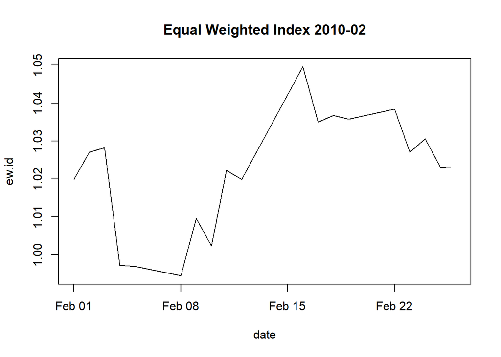

```r
crsp.ew.2010.02=crsp.ew %>% filter(yymm=='2010-02')
plot(crsp.ew.2010.02$ew~
       as.Date(crsp.ew.2010.02$date),
     type='l',xlab='date',ylab='ew.id',
     main='Equal Weighted Index 2010-02')
```

## Step 5. Cumulative Returns over the all periods

- Recalculate each day’s return from the monthly return
- For days that are not the first day of a month, the daily return is simply the cumulative return today/the cumulative return yesterday-1
- For days that are the first day of a month, the daily return is similar the cumulative return we calculated before.
- Recalculate the cumulative return for the entire period
- Visualize the cumulative returns

```r
# calculate return on index on each day
crsp.ew = crsp.ew %>%
  group_by(yymm) %>%
  arrange(date) %>%
  mutate(ret=ew/lag(ew,1)-1) %>% ungroup()
head(crsp.ew)
```

```
## # A tibble: 6 x 4
##   date          ew yymm          ret
##   <chr>      <dbl> <chr>       <dbl>
## 1 2010-01-04  1.02 2010-01 NA
## 2 2010-01-05  1.03 2010-01  0.0114
## 3 2010-01-06  1.04 2010-01  0.0112
## 4 2010-01-07  1.05 2010-01  0.00908
## 5 2010-01-08  1.06 2010-01  0.00769
## 6 2010-01-11  1.06 2010-01  0.000674
```

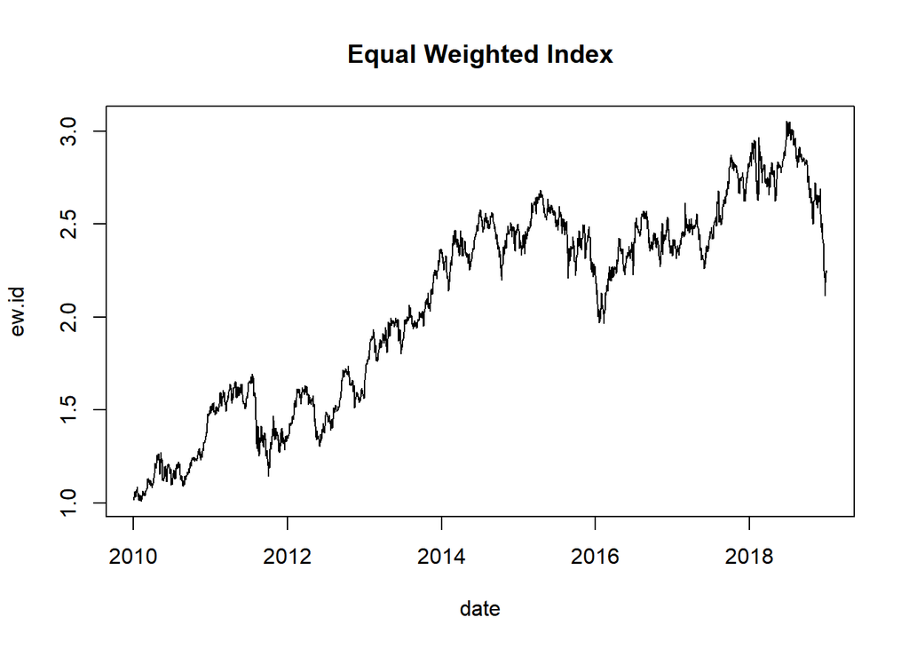

```r
# fill the first date of each month with the return on that day
crsp.ew = crsp.ew %>%
  mutate(ret=ifelse(is.na(ret),ew-1,ret))

# cumulative returns over all periods
crsp.ew = crsp.ew %>%
  arrange(date) %>%
  mutate(ew.all = cumprod(ret+1))

# visualise equal weight index cumulative returns
plot(crsp.ew$ew.all~as.Date(crsp.ew$date),
     type='l',xlab='date',ylab='ew.id',
     main='Equal Weighted Index')
```

```r
save(crsp.ew,file='crsp.ew.RData')
```

# Value Weighted Portfolio, Monthly Reallocation

## Step 1: Grab all stocks’ daily returns, close prices and shares outstanding.

```r
print(head(crsp.sample))
```

```
##   permno       date          ret   prc shrout
## 1  11600 2010-01-04  0.004549436 35.33 147000
## 2  11600 2010-01-05 -0.011887969 34.91 147000
## 3  11600 2010-01-06  0.006588357 35.14 147000
## 4  11600 2010-01-07  0.013090469 35.60 147000
## 5  11600 2010-01-08  0.000000000 35.60 147000
## 6  11600 2010-01-11  0.012921430 36.06 147000
```

## Step 2: Calculate market cap

- market cap = price * shares outstanding
- In CRSP, the price is negative to indicate it is a bid/ask average and not an actual closing price. Adjust the price using the abs() function to change it to positive.
- The permno in the downloaded data is numeric by default and we change it to the character type.

```r
crsp.sample = crsp.sample %>%
  mutate(me=abs(prc)*shrout) %>%
  select(permno,date,ret,me) %>%
  mutate(permno=as.character(permno))

# handling missing returns
crsp.ret = spread(crsp.sample[,c("permno","date","ret")],permno,ret)
crsp.ret = gather(crsp.ret,key=permno,value=ret,-date)
crsp.ret = crsp.ret %>%
  mutate(ret=ifelse(is.na(ret),0,ret))

# seperate market cap into another dataframe and merge back onto returns
crsp.me = crsp.sample %>% select(permno,date,me)
crsp.sample = crsp.ret %>% left_join(crsp.me,by=c("permno","date"))
head(crsp.sample)
```

```
##         date permno          ret      me
## 1 2010-01-04  11600  0.004549436 5193510
## 2 2010-01-05  11600 -0.011887969 5131770
## 3 2010-01-06  11600  0.006588357 5165580
## 4 2010-01-07  11600  0.013090469 5233200
## 5 2010-01-08  11600  0.000000000 5233200
## 6 2010-01-11  11600  0.012921430 5300820
```

## Step 3: Calculate the market cap for weighing at the beginning of each month.

- Since the market cap used for calulating weights is the market cap of last date from last month, we first lag the market cap by 1 day.
- Keep the first value of lag.me for each month which is the last date me from last month.

```r
# lag me
crsp.vw = crsp.sample %>%
  group_by(permno) %>%
  arrange(date) %>%
  mutate(lag.me=lag(me,1)) %>% ungroup()

# keep the first value of lag.me for each month which is the last date me from last month
crsp.vw = crsp.vw %>%
  mutate(yymm=substr(date,1,7)) %>%
  group_by(permno,yymm) %>%
  arrange(date) %>%
  mutate(lag.me=first(lag.me)) %>% ungroup()
head(crsp.vw)
```

```
## # A tibble: 6 x 6
##   date       permno     ret       me lag.me yymm
##   <date>     <chr>    <dbl>    <dbl>  <dbl> <chr>
## 1 2010-01-04 11600  0.00455 5193510.     NA 2010-01
## 2 2010-01-04 13610  0.0354  1424607.     NA 2010-01
## 3 2010-01-04 39731  0.0724     9377.     NA 2010-01
## 4 2010-01-04 79089  0.00417 2254530.     NA 2010-01
## 5 2010-01-04 83148  0.0224   168190.     NA 2010-01
## 6 2010-01-04 85459  0.0104  9915595.     NA 2010-01
```

```r
# remove the first month of entire data as all the lag.me are NA
crsp.vw = crsp.vw %>% filter(yymm!=first(yymm))
head(crsp.vw)
```

```
## # A tibble: 6 x 6
##   date       permno     ret       me   lag.me yymm
##   <date>     <chr>    <dbl>    <dbl>    <dbl> <chr>
## 1 2010-02-01 11600  0.00149 4936260. 4928910. 2010-02
## 2 2010-02-01 13610  0.0224  1327669. 1298550  2010-02
## 3 2010-02-01 39731  0.0990    12772.   11621. 2010-02
## 4 2010-02-01 79089  0.0119  2210376. 2184285. 2010-02
## 5 2010-02-01 83148  0.00315  167926.  167399. 2010-02
## 6 2010-02-01 85459  0.0136  9591425. 9462760. 2010-02
```

```r
# fill lag.me with 0 if NA
crsp.vw = crsp.vw %>% mutate(lag.me=ifelse(is.na(lag.me),0,lag.me))
```

## Step 4: Calculate the wgt of each stock using lag.me/sum(lag.me)

```r
crsp.vw = crsp.vw %>%
  group_by(date) %>%
  mutate(wgt=lag.me/sum(lag.me,na.rm=T)) %>%
  ungroup()
head(crsp.vw)
```

```
## # A tibble: 6 x 7
##   date       permno     ret       me   lag.me yymm         wgt
##   <date>     <chr>    <dbl>    <dbl>    <dbl> <chr>      <dbl>
## 1 2010-02-01 11600  0.00149 4936260. 4928910. 2010-02 0.218
## 2 2010-02-01 13610  0.0224  1327669. 1298550  2010-02 0.0574
## 3 2010-02-01 39731  0.0990    12772.   11621. 2010-02 0.000514
## 4 2010-02-01 79089  0.0119  2210376. 2184285. 2010-02 0.0966
## 5 2010-02-01 83148  0.00315  167926.  167399. 2010-02 0.00740
## 6 2010-02-01 85459  0.0136  9591425. 9462760. 2010-02 0.419
```

## Calculate the cumulative returns of each individual stock over each month

```r
crsp.vw = crsp.vw %>%
  group_by(yymm,permno) %>%
  arrange(date) %>%
  mutate(cumret=cumprod(ret+1)) %>% ungroup()
crsp.vw = crsp.vw %>% arrange(date,permno)
head(crsp.vw)
```

```
## # A tibble: 6 x 8
##   date       permno     ret       me   lag.me yymm         wgt cumret
##   <date>     <chr>    <dbl>    <dbl>    <dbl> <chr>      <dbl>  <dbl>
## 1 2010-02-01 11600  0.00149 4936260. 4928910. 2010-02 0.218      1.00
## 2 2010-02-01 13610  0.0224  1327669. 1298550  2010-02 0.0574     1.02
## 3 2010-02-01 39731  0.0990    12772.   11621. 2010-02 0.000514   1.10
## 4 2010-02-01 79089  0.0119  2210376. 2184285. 2010-02 0.0966     1.01
## 5 2010-02-01 83148  0.00315  167926.  167399. 2010-02 0.00740    1.00
## 6 2010-02-01 85459  0.0136  9591425. 9462760. 2010-02 0.419      1.01
```

## Step 7: The Value-Weighted index is sum(wgt(i)*cumret(i))

```r
crsp.vw = crsp.vw %>%
  mutate(vw=wgt*cumret)
head(crsp.vw)
```

```
## # A tibble: 6 x 9
##   date       permno     ret       me   lag.me yymm       wgt cumret      vw
##   <date>     <chr>    <dbl>    <dbl>    <dbl> <chr>    <dbl>  <dbl>   <dbl>
## 1 2010-02-01 11600  0.00149 4936260. 4928910. 2010-~ 2.18e-1   1.00 2.18e-1
## 2 2010-02-01 13610  0.0224  1327669. 1298550  2010-~ 5.74e-2   1.02 5.87e-2
## 3 2010-02-01 39731  0.0990    12772.   11621. 2010-~ 5.14e-4   1.10 5.65e-4
## 4 2010-02-01 79089  0.0119  2210376. 2184285. 2010-~ 9.66e-2   1.01 9.78e-2
## 5 2010-02-01 83148  0.00315  167926.  167399. 2010-~ 7.40e-3   1.00 7.43e-3
## 6 2010-02-01 85459  0.0136  9591425. 9462760. 2010-~ 4.19e-1   1.01 4.24e-1
```

```r
crsp.vw = crsp.vw %>%
  group_by(date) %>%
  summarise(vw=sum(vw),
            yymm=first(yymm)) %>%
  ungroup()
head(crsp.vw)
```

```
## # A tibble: 6 x 3
##   date          vw yymm
##   <date>     <dbl> <chr>
## 1 2010-02-01 1.02  2010-02
## 2 2010-02-02 1.03  2010-02
## 3 2010-02-03 0.992 2010-02
## 4 2010-02-04 0.967 2010-02
## 5 2010-02-05 0.965 2010-02
## 6 2010-02-08 0.970 2010-02
```

## Example: 2010-02

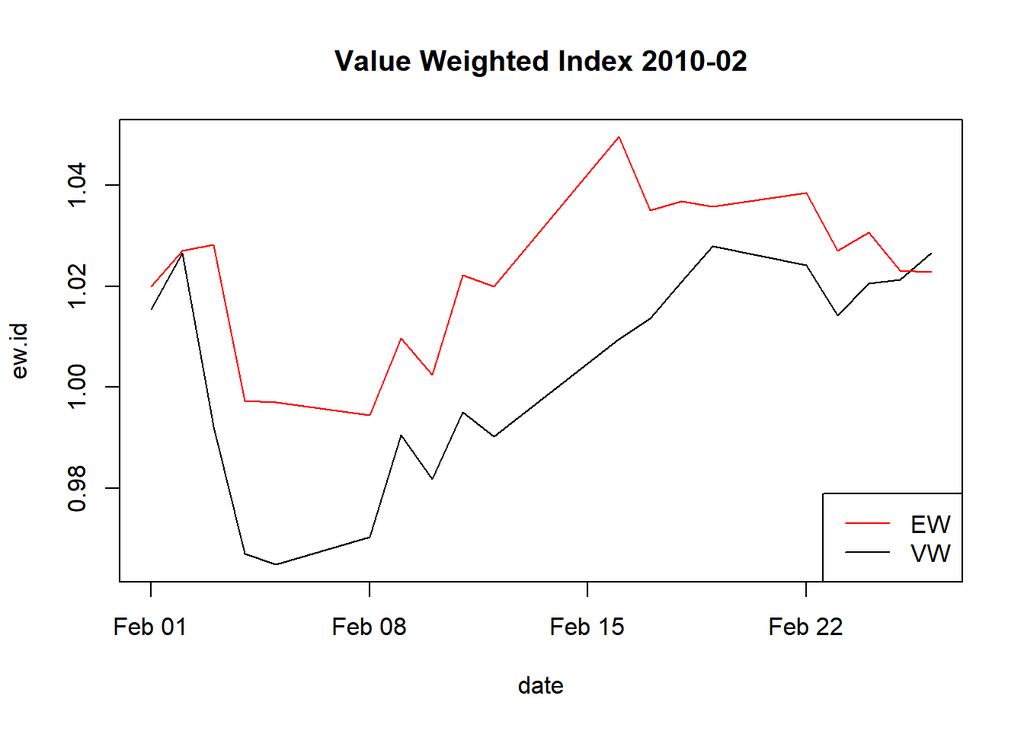

```r
crsp.vw.2010.02 = crsp.vw %>% filter(yymm=='2010-02')
yrange=range(c(crsp.ew.2010.02$ew,crsp.vw.2010.02$vw))
plot(crsp.vw.2010.02$vw~as.Date(crsp.vw.2010.02$date),
     type='l',xlab='date',ylab='ew.id',
     main='Value Weighted Index 2010-02',
     ylim=yrange)
lines(crsp.ew.2010.02$ew~as.Date(crsp.ew.2010.02$date),
      col='red')
legend("bottomright",c("EW","VW"),col=c("red","black"),lty=c(1,1))
```

Step 8: Cumulative Returns over the all periods

```r
# calculate return on index on each day
crsp.vw = crsp.vw %>%
  group_by(yymm) %>%
  arrange(date) %>%
  mutate(ret=vw/lag(vw,1)-1) %>% ungroup()
head(crsp.vw)
```

```
## # A tibble: 6 x 4
##   date          vw yymm         ret
##   <date>     <dbl> <chr>      <dbl>
## 1 2010-02-01 1.02  2010-02 NA
## 2 2010-02-02 1.03  2010-02  0.0110
## 3 2010-02-03 0.992 2010-02 -0.0335
## 4 2010-02-04 0.967 2010-02 -0.0254
## 5 2010-02-05 0.965 2010-02 -0.00218
## 6 2010-02-08 0.970 2010-02  0.00564
```

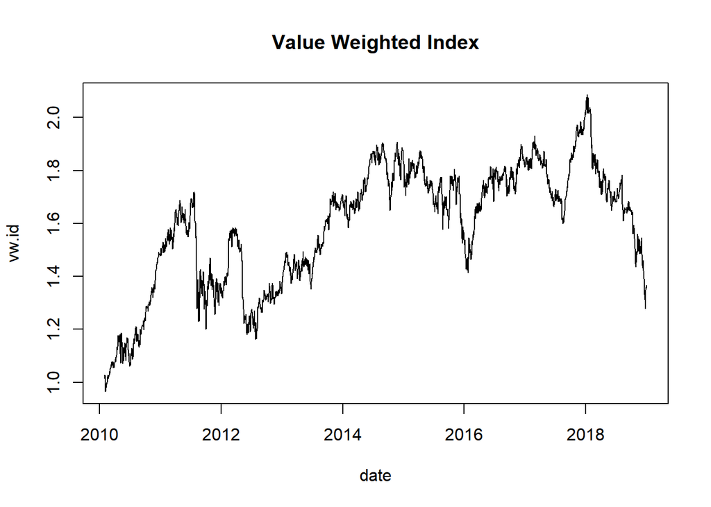

```r
# fill the first date of each month with the return on that day
crsp.vw = crsp.vw %>%
  mutate(ret=ifelse(is.na(ret),vw-1,ret))

# cumulative returns over all periods
crsp.vw = crsp.vw %>%
  arrange(date) %>%
  mutate(vw.all = cumprod(ret+1))

# visualise equal weight index cumulative returns
plot(crsp.vw$vw.all~as.Date(crsp.vw$date),
     type='l',xlab='date',ylab='vw.id',
     main='Value Weighted Index')
```

```r
save(crsp.vw,file='crsp.vw.RData')
```